# **A mathematical model to describe the melanoma dynamics under effects of macrophage inhibition and CAR T-cell therapy**

*Algorithms developed by* Guilherme Rodrigues, Jairo G. Silva, Daniela S. Santurio, and Paulo F. A. Mancera

```python
import matplotlib.pyplot as plt
import matplotlib.ticker
import numpy as np
from mpl_toolkits.mplot3d import Axes3D
from scipy.integrate import odeint
from scipy.integrate import solve_ivp
import pylab as pl
import sympy as sm
```

## **Parameters**

```python
alpha1=0.69 #Natural proliferation rate of tumor cells

beta1=2.3*10**-10 #Tumor proliferation rate due to the pro-tumor action of TAM

alpha2=10**-7 #Rate of macrophage recruitment/proliferation promoted by the tumor

alpha3=5*10**-8 #Expansion/proliferation rate of CAR-T cells due to contact with tumor antigen

K1=10**9 #Tumor cell carrying capacity

K2=10**9  #Macrophage carrying capacity

mu1=10**-7 #Rate of tumor cell death due to the cytotoxic action of CAR-T cells. This value was estimated by Kuznetzov et al. for Lymphoma in mice.

kappa2=0.34 #Macrophage apoptosis rate

gamma3=4*10**-8 ##Rate of immunosuppression/inhibition of CAR-T cells due to tumor cells

kappa3=0.13 #Apoptosis rate of CAR-T cells

theta3=10**-10 #Rate of immunosuppression caused by TAM on CAR T cells
```

## **Mathematical Model**

The mathematical model is given by

$$\left\{\begin{array}{lll} \dfrac{dT}{dt}=\alpha_{1}T\left(1-\dfrac{T}{K_{1}}\right)(1+\beta_{1}M)-\mu_1CT,\\ \\ \dfrac{dM}{dt}=\alpha_{2}MT\left(1-\dfrac{M}{K_{2}} \right)-\kappa_{2}M,\\ \\ \dfrac{dC}{dt}=\alpha_{3}CT-\gamma_{3}CT-\theta_{3}MC-\kappa_{3}C. \end{array}\right.$$

where $T$, $M$ and $C$ represent the number of tumor cells, TAM and CAR-T, respectively.

```python
def sis(TMC, t):
    T,M,C=TMC
    dT=alpha1*T*(1-(T/K1))*(1+(beta1*M))-mu1*T*C
    dM=alpha2*T*M*(1-(M/K2))-kappa2*M
    dC=alpha3*C*T-gamma3*C*T-theta3*M*C-kappa3*C
    return dT, dM, dC
```

## **Stability of the equilibrium points associated with the model**

**Equilibrium point $E_1=(K_1,0,0)$**: It will be linearly asymptotically stable if

$$\alpha_2<\dfrac{\kappa_2}{K_1}\text{ e } \alpha_3<\dfrac{\kappa_3}{K_1}+\gamma_3$$

**Equilibrium point $E_2=\left(K_1,K_2(1-\dfrac{\kappa_2}{\alpha_2K_1},0\right)$, with $\alpha_2>\dfrac{\kappa_2}{\alpha_2K_1}$**: It will be linearly asymptotically stable if

$$\alpha_2>\dfrac{K_2\beta_1\kappa_2}{K_1(K_2\beta_1+1)}$$$$\alpha_2 > \dfrac{\kappa_2}{K_1} $$$$\alpha_3 < \dfrac{K_2\theta_3}{K_1}\left(1-\dfrac{\kappa_2}{K_1\alpha_2}\right)+\kappa_3+\gamma_3 $$

**Equilibrium point $E_3=\left(\dfrac{\kappa_3}{\beta_3}, 0, \dfrac{\alpha_1}{\mu_1}\left(1-\dfrac{\kappa_3}{\beta_3K_1} \right)\right)$, with $\alpha_3>\dfrac{\kappa_3}{K_1}+\gamma_3$**: It will be linearly asymptotically stable if $$\alpha_3>\dfrac{\alpha_2\kappa_3}{\kappa_2}+\gamma_3$$

$$\alpha_3>\gamma_3 $$$$ \alpha_3>\dfrac{\kappa_3}{K_1}+\gamma_3 $$

**Coexistence equilibrium point** $E^*=(T^*, M^*, C^*)$

The equilibrium point is given by:

$$E^*=\left(\dfrac{\alpha_2(K_2\theta_3+\kappa_3)+\sqrt{\delta}}{2\alpha_2\beta_3}, \dfrac{\beta_3T^{*}-\kappa_3}{\theta_3}, \dfrac{\alpha_1}{\mu_1}\left(1-\dfrac{T^*}{K_1}\right)\left(1+\beta_1M^*(T^*)\right)\right)$$

where $\delta=\alpha_2(K_2^2\alpha_2\theta_3^2+2K_2\alpha_2\kappa_3\theta_3-4K_2\beta_3\kappa_2\theta_3+\alpha_2\kappa_3^2)$.

The point $E^*$ has some existence conditions. The first concerns the coordinate $T^*$, where it belongs to the set of reals if $$\delta\geq0\Rightarrow \alpha_3\leq\dfrac{\alpha_2(K_2^2\theta_3^2+2K_2\kappa_3\theta_3+\kappa_3^2)}{4K_2\kappa_2\theta_3}+\gamma_3.$$

Furthermore, for $T^*\geq0$, the condition to be satisfied is

$$\alpha_3\geq\gamma_3.$$

Biologically, $\alpha_3$ must always be greater than $\gamma_3$ so that the immunotherapeutic treatment can have an effect and the CAR-T cells have a chance to expand. With regard to the $M^*$ coordinate, its positivity is conditional on

$$\alpha_3\leq\dfrac{\alpha_2\kappa_3}{\kappa_2}+\gamma_3$$

## **Stability analysis of equilibrium points using the parameter set**

At first, we attempted to analyze numerical stability by varying the parameter $\alpha_3$.

```python
alpha3_list=np.linspace(10**-10, 5*10**-6,10)

T, M, C = sm.symbols('T,M,C')

for alpha3 in alpha3_list:
  print("α3 = ", alpha3, "\n")
  print('Condição de estabildade E1')
  print('alpha2 =',alpha2,'<', kappa2/K1)
  print('alpha3 =',alpha3,'<', kappa3/K1+gamma3)
  print('-----------------------------------')

  print('Condição de estabildade E2')
  print('alpha2 =',alpha2,'>',  (K2*beta1*kappa2)/(K1*(K2*beta1+1)))
  print('alpha2 =',alpha2,'>',  kappa2/K1)
  print('alpha3 =',alpha3,'<',  ((K2*theta3)/K1)*(1-(kappa2/(K1*alpha2)))+gamma3+(kappa3/K1))
  print('-----------------------------------')

  print('Condição de estabildade E3')
  print('alpha3 =',alpha3,'>',  ((alpha2*kappa3)/kappa2)+gamma3)
  print('alpha3 =',alpha3,'>',  gamma3)
  print('alpha3 =',alpha3,'>',  (kappa3/K1)+gamma3)
  print('-----------------------------------')

  print('Condição de existência E*')
  print('Para não ser complexo a condição é alpha3 =',alpha3,'<=',  ((alpha2*(K2**2*theta3**2+2*K2*kappa3*theta3+kappa3**2))/(4*K2*kappa2*theta3)+gamma3))
  print('alpha3 =',alpha3,'>=',  gamma3)
  print('alpha3 =',alpha3,'<=',  ((alpha2*kappa3)/kappa2)+gamma3)
  print('-----------------------------------')

  P = alpha1*T*(1-(T/K1))*(1+(beta1*M))-mu1*T*C
  Q = alpha2*T*M*(1-(M/K2))-kappa2*M
  S = alpha3*C*T-gamma3*C*T-theta3*M*C-kappa3*C

  # Set P(x,y)=0 and Q(x,y)=0.
  Teqn = sm.Eq(P, 0)
  Meqn = sm.Eq(Q, 0)
  Ceqn = sm.Eq(S, 0)

  criticalpoints = sm.solve((Teqn, Meqn, Ceqn), T, M, C)
  print('-------------------------------------------')
  print('-------------------------------------------',"\n")
  # print("α3 = ", alpha3, "\n")
  print(criticalpoints,'\n')

  eqMat = sm.Matrix([P, Q, S ])
  Mat = sm.Matrix([ T, M, C])
  jacMat = eqMat.jacobian(Mat)
  print('Jacobian %s' % jacMat)
  print('---------------------')

  # iterate through list of equilibria
  contador = 1
  for PE in criticalpoints:
      # print("PE", contador,"= (", np.format_float_scientific(PE[0], precision = 3, exp_digits=1),",",
      #   np.format_float_scientific(PE[1], precision = 3, exp_digits=1),",",
      #   np.format_float_scientific(PE[2], precision = 3, exp_digits=1),")\n")
      print("PE", contador,"= (", PE[0],",", PE[1],",", PE[2],")\n")


      contador = contador+1

      eqmat = jacMat.subs([ (T, PE[0]), (M, PE[1]), (C, PE[2])])
      print(eqmat)

      elgs = eqmat.eigenvals()
      av=[]
      for autov in elgs.keys():
        av.append(autov)
      print(av)

      print('Os autovalores associados a matriz jacobiana avaliada no ponto de equilíbrio são %s, %s and %s:'
            %(av[0], av[1], av[2]))

      # print('Os autovalores associados a matriz jacobiana avaliada no ponto de equilíbrio (%s, %s, %s) are %s, %s and %s:'
      #       %(PE[0], PE[1], PE[2], av[0], av[1], av[2]))
      print('-------------------------------------------')
```

```
α3 =  1e-10

Condição de estabildade E1
alpha2 = 1e-07 < 3.4e-10
alpha3 = 1e-10 < 4.013e-08
-----------------------------------
Condição de estabildade E2
alpha2 = 1e-07 > 6.357723577235773e-11
alpha2 = 1e-07 > 3.4e-10
alpha3 = 1e-10 < 4.022966e-08
-----------------------------------
Condição de estabildade E3
alpha3 = 1e-10 > 7.823529411764706e-08
alpha3 = 1e-10 > 4e-08
alpha3 = 1e-10 > 4.013e-08
-----------------------------------
Condição de existência E*
Para não ser complexo a condição é alpha3 = 1e-10 <= 7.88970588235294e-08
alpha3 = 1e-10 >= 4e-08
alpha3 = 1e-10 <= 7.823529411764706e-08
-----------------------------------
-------------------------------------------
-------------------------------------------

[(-6984450.25073458, 1486795650.04310, 9324217.52589638), (-3258145.36340852, 0.0, 6922481.20300752), (0.0, 0.0, 0.0), (635772.357723577, -4347826086.95652, 0.0), (1220039.22316565, -1786795650.04310, 4059396.63049460), (1000000000.00000, 0.0, 0.0), (1000000000.00000, 996600000.000000, 0.0)]

Jacobian Matrix([[-1.0e-7*C - 6.9e-10*T*(2.3e-10*M + 1) + 0.69*(1 - T/1000000000)*(2.3e-10*M + 1), 1.587e-10*T*(1 - T/1000000000), -1.0e-7*T], [1.0e-7*M*(1 - M/1000000000), -1.0e-16*M*T + 1.0e-7*T*(1 - M/1000000000) - 0.34, 0], [-3.99e-8*C, -1.0e-10*C, -1.0e-10*M - 3.99e-8*T - 0.13]])
---------------------
PE 1 = ( -6984450.25073458 , 1486795650.04310 , 9324217.52589638 )

Matrix([[0.00646728292779819, -0.00111617404473148, 0.698445025073458], [-72.3765654943976, 1.03844502507346, 0], [-0.372036279283265, -0.000932421752589638, 0]])
[1.12902827866768 - 2.61128113008394e-65*I, -0.0420579853332102 - 0.528184056728691*I, -0.0420579853332102 + 0.528184056728691*I]
Os autovalores associados a matriz jacobiana avaliada no ponto de equilíbrio são 1.12902827866768 - 2.61128113008394e-65*I, -0.0420579853332102 - 0.528184056728691*I and -0.0420579853332102 + 0.528184056728691*I:
-------------------------------------------
PE 2 = ( -3258145.36340852 , 0.0 , 6922481.20300752 )

Matrix([[0.00224812030075183, -0.000518752350801817, 0.325814536340852], [0, -0.665814536340852, 0], [-0.276207000000000, -0.000692248120300752, 0]])
[-0.665814536340852 + 9.86412301745315e-65*I, 0.00112406015037592 - 0.299984986504118*I, 0.00112406015037592 + 0.299984986504118*I]
Os autovalores associados a matriz jacobiana avaliada no ponto de equilíbrio são -0.665814536340852 + 9.86412301745315e-65*I, 0.00112406015037592 - 0.299984986504118*I and 0.00112406015037592 + 0.299984986504118*I:
-------------------------------------------
```

[output cut: 645 more lines]

```
[-0.848160420000000, -99.6600000000000, 4959.77034000000]
Os autovalores associados a matriz jacobiana avaliada no ponto de equilíbrio são -0.848160420000000, -99.6600000000000 and 4959.77034000000:
-------------------------------------------
PE 6 = ( 23185.4838709677 - 260788.842618781*I , -150000000.0 - 12935126593.8915*I , 6667149.02479839 - 20525832.5895986*I )

Matrix([[-0.666714902479839 + 0.69*(0.9655 - 2.97507911659505*I)*(0.999976814516129 + 0.000260788842618781*I) - 6.9e-10*(0.9655 - 2.97507911659505*I)*(23185.4838709677 - 260788.842618781*I) + 2.05258325895986*I, 1.587e-10*(0.999976814516129 + 0.000260788842618781*I)*(23185.4838709677 - 260788.842618…
[-1.74556192433126 - 0.17361704254723*I, 0.764410873080225 + 0.283817992596834*I, 1.31935240534378 - 0.0839007342969959*I]
Os autovalores associados a matriz jacobiana avaliada no ponto de equilíbrio são -1.74556192433126 - 0.17361704254723*I, 0.764410873080225 + 0.283817992596834*I and 1.31935240534378 - 0.0839007342969959*I:
-------------------------------------------
PE 7 = ( 23185.4838709677 + 260788.842618781*I , -150000000.0 + 12935126593.8915*I , 6667149.02479839 + 20525832.5895986*I )

Matrix([[-0.666714902479839 - 2.05258325895986*I - 6.9e-10*(0.9655 + 2.97507911659505*I)*(23185.4838709677 + 260788.842618781*I) + 0.69*(0.9655 + 2.97507911659505*I)*(0.999976814516129 - 0.000260788842618781*I), 1.587e-10*(0.999976814516129 - 0.000260788842618781*I)*(23185.4838709677 + 260788.842618…
[-1.74556192433126 + 0.17361704254723*I, 0.764410873080225 - 0.283817992596834*I, 1.31935240534378 + 0.0839007342969959*I]
Os autovalores associados a matriz jacobiana avaliada no ponto de equilíbrio são -1.74556192433126 + 0.17361704254723*I, 0.764410873080225 - 0.283817992596834*I and 1.31935240534378 + 0.0839007342969959*I:
-------------------------------------------
```

The numerical stability analyses carried out above give us the following results:

|  | $\alpha_3=10^{-10}$ | $\alpha_3=5.556\cdot10^{-7}$ | $\alpha_3=1.111\cdot10^{-6}$ | $\alpha_3=1.666\cdot10^{-6}$ | $\alpha_3=2.222\cdot10^{-6}$ | $\alpha_3=2.777\cdot10^{-6}$ | $\alpha_3=3.333\cdot10^{-6}$ | $\alpha_3=3.333\cdot10^{-6}$ | $\alpha_3=4.999\cdot10^{-6}$ |
| --- | --- | --- | --- | --- | --- | --- | --- | --- | --- |
| $E_1=(K_1,0,0)$ | Unstable | Unstable | Unstable | Unstable | Unstable | Unstable | Unstable | Unstable | Unstable |
| $E_2=\left(K_1,K_2(1-\dfrac{\kappa_2}{\alpha_2K_1},0\right)$ | Stable | Unstable | Unstable | Unstable | Unstable | Unstable | Unstable | Unstable | Unstable |
| $E_3=\left(\dfrac{\kappa_3}{\beta_3}, 0, \dfrac{\alpha_1}{\mu_1}\left(1-\dfrac{\kappa_3}{\beta_3K_1} \right)\right)$ | Does not exist | Spiral stable | Spiral stable | Spiral stable | Spiral stable | Spiral stable | Spiral stable | Spiral stable | Spiral stable |

These findings indicate that we can rewrite the stability conditions of the points shown above as functions of $\alpha_2$. Next, we will do the same analysis, but fixing the parameter $\alpha_3$ and varying $\alpha_2$ to evaluate the existence and stability of the equilibrium points.

```python
alpha3 = 5*10**-8
alpha2_list=np.linspace(10**-8, 8*10**-8,10)

T, M, C = sm.symbols('T,M,C')

for alpha2 in alpha2_list:
  print("α2 = ", alpha2, "\n")
  print('Condição de estabildade E1')
  print('alpha2 =',alpha2,'<', kappa2/K1)
  print('alpha3 =',alpha3,'<', kappa3/K1+gamma3)
  print('-----------------------------------')

  print('Condição de estabildade E2')
  print('alpha2 =',alpha2,'>',  (K2*beta1*kappa2)/(K1*(K2*beta1+1)))
  print('alpha2 =',alpha2,'>',  kappa2/K1)
  print('alpha3 =',alpha3,'<',  ((K2*theta3)/K1)*(1-(kappa2/(K1*alpha2)))+gamma3+(kappa3/K1))
  print('-----------------------------------')

  print('Condição de estabildade E3')
  print('alpha3 =',alpha3,'>',  ((alpha2*kappa3)/kappa2)+gamma3)
  print('alpha3 =',alpha3,'>',  gamma3)
  print('alpha3 =',alpha3,'>',  (kappa3/K1)+gamma3)
  print('-----------------------------------')

  print('Condição de existência E*')
  print('Para não ser complexo a condição é alpha3 =',alpha3,'<=',  ((alpha2*(K2**2*theta3**2+2*K2*kappa3*theta3+kappa3**2))/(4*K2*kappa2*theta3)+gamma3))
  print('alpha3 =',alpha3,'>=',  gamma3)
  print('alpha3 =',alpha3,'<=',  ((alpha2*kappa3)/kappa2)+gamma3)
  print('-----------------------------------')

  P = alpha1*T*(1-(T/K1))*(1+(beta1*M))-mu1*T*C
  Q = alpha2*T*M*(1-(M/K2))-kappa2*M
  S = alpha3*C*T-gamma3*C*T-theta3*M*C-kappa3*C

  # Set P(x,y)=0 and Q(x,y)=0.
  Teqn = sm.Eq(P, 0)
  Meqn = sm.Eq(Q, 0)
  Ceqn = sm.Eq(S, 0)

  criticalpoints = sm.solve((Teqn, Meqn, Ceqn), T, M, C)
  print('-------------------------------------------')
  print('-------------------------------------------',"\n")
  # print("α3 = ", alpha3, "\n")
  print(criticalpoints,'\n')

  eqMat = sm.Matrix([P, Q, S ])
  Mat = sm.Matrix([ T, M, C])
  jacMat = eqMat.jacobian(Mat)
  print('Jacobian %s' % jacMat)
  print('---------------------')

  # iterate through list of equilibria
  contador = 1
  for PE in criticalpoints:
      # print("PE", contador,"= (", np.format_float_scientific(PE[0], precision = 3, exp_digits=1),",",
      #   np.format_float_scientific(PE[1], precision = 3, exp_digits=1),",",
      #   np.format_float_scientific(PE[2], precision = 3, exp_digits=1),")\n")
      print("PE", contador,"= (", PE[0],",", PE[1],",", PE[2],")\n")


      contador = contador+1

      eqmat = jacMat.subs([ (T, PE[0]), (M, PE[1]), (C, PE[2])])
      print(eqmat)

      elgs = eqmat.eigenvals()
      av=[]
      for autov in elgs.keys():
        av.append(autov)
      print(av)

      print('Os autovalores associados a matriz jacobiana avaliada no ponto de equilíbrio são %s, %s and %s:'
            %(av[0], av[1], av[2]))

      # print('Os autovalores associados a matriz jacobiana avaliada no ponto de equilíbrio (%s, %s, %s) are %s, %s and %s:'
      #       %(PE[0], PE[1], PE[2], av[0], av[1], av[2]))
      print('-------------------------------------------')
```

```
α2 =  1e-08

Condição de estabildade E1
alpha2 = 1e-08 < 3.4e-10
alpha3 = 5e-08 < 4.013e-08
-----------------------------------
Condição de estabildade E2
alpha2 = 1e-08 > 6.357723577235773e-11
alpha2 = 1e-08 > 3.4e-10
alpha3 = 5e-08 < 4.0226600000000005e-08
-----------------------------------
Condição de estabildade E3
alpha3 = 5e-08 > 4.382352941176471e-08
alpha3 = 5e-08 > 4e-08
alpha3 = 5e-08 > 4.013e-08
-----------------------------------
Condição de existência E*
Para não ser complexo a condição é alpha3 = 5e-08 <= 4.3889705882352944e-08
alpha3 = 5e-08 >= 4e-08
alpha3 = 5e-08 <= 4.382352941176471e-08
-----------------------------------
-------------------------------------------
-------------------------------------------

[(0.0, 0.0, 0.0), (6357723.57723577, -4347826086.95652, 0.0), (13000000.0000000, 0.0, 6810300.00000000), (1000000000.00000, 0.0, 0.0), (1000000000.00000, 966000000.000000, 0.0), (11500000.0 - 14413535.3053996*I, -150000000.0 - 1441353530.53996*I, 6618307.5 - 2165100.37882999*I), (11500000.0 + 144135…

Jacobian Matrix([[-1.0e-7*C - 6.9e-10*T*(2.3e-10*M + 1) + 0.69*(1 - T/1000000000)*(2.3e-10*M + 1), 1.587e-10*T*(1 - T/1000000000), -1.0e-7*T], [1.0e-8*M*(1 - M/1000000000), -1.0e-17*M*T + 1.0e-8*T*(1 - M/1000000000) - 0.34, 0], [1.0e-8*C, -1.0e-10*C, -1.0e-10*M + 1.0e-8*T - 0.13]])
---------------------
PE 1 = ( 0.0 , 0.0 , 0.0 )

Matrix([[0.690000000000000, 0, 0], [0, -0.340000000000000, 0], [0, 0, -0.130000000000000]])
[0.690000000000000, -0.340000000000000, -0.130000000000000]
Os autovalores associados a matriz jacobiana avaliada no ponto de equilíbrio são 0.690000000000000, -0.340000000000000 and -0.130000000000000:
-------------------------------------------
PE 2 = ( 6357723.57723577 , -4347826086.95652 , 0.0 )

Matrix([[-1.11022302462516e-16, 0.00100255597469760, -0.635772357723577], [-232.514177693762, 0.276422764227642, 0], [0, 0, 0.368359844468010]])
[0.138211382113821 - 0.462607924600269*I, 0.138211382113821 + 0.462607924600269*I, 0.368359844468010]
Os autovalores associados a matriz jacobiana avaliada no ponto de equilíbrio são 0.138211382113821 - 0.462607924600269*I, 0.138211382113821 + 0.462607924600269*I and 0.368359844468010:
-------------------------------------------
```

[output cut: 645 more lines]

```
[-1.35576519652951 + 1.04451245203358e-64*I, 0.000373761949988602 - 0.386614435200786*I, 0.000373761949988602 + 0.386614435200786*I]
Os autovalores associados a matriz jacobiana avaliada no ponto de equilíbrio são -1.35576519652951 + 1.04451245203358e-64*I, 0.000373761949988602 - 0.386614435200786*I and 0.000373761949988602 + 0.386614435200786*I:
-------------------------------------------
PE 6 = ( 1000000000.00000 , 0.0 , 0.0 )

Matrix([[-0.690000000000000, 0, -100.000000000000], [0, 79.6600000000000, 0], [0, 0, 9.87000000000000]])
[-0.690000000000000, 79.6600000000000, 9.87000000000000]
Os autovalores associados a matriz jacobiana avaliada no ponto de equilíbrio são -0.690000000000000, 79.6600000000000 and 9.87000000000000:
-------------------------------------------
PE 7 = ( 1000000000.00000 , 995750000.000000 , 0.0 )

Matrix([[-0.848025525000000, 0, -100.000000000000], [0.338554999999998, -79.6600000000000, 0], [0, 0, 9.77042500000000]])
[-0.848025525000000, -79.6600000000000, 9.77042500000000]
Os autovalores associados a matriz jacobiana avaliada no ponto de equilíbrio são -0.848025525000000, -79.6600000000000 and 9.77042500000000:
-------------------------------------------
```

Numerical stability analyses varying the $\alpha_2$ parameter provide the following results:

[output not shown]

Next, we construct graphs to show the stability of the equilibrium points.

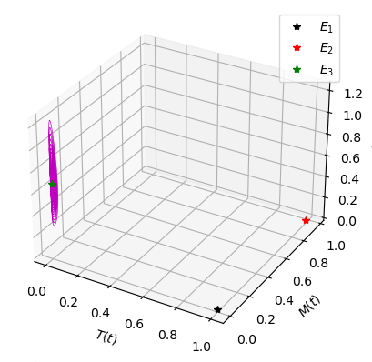

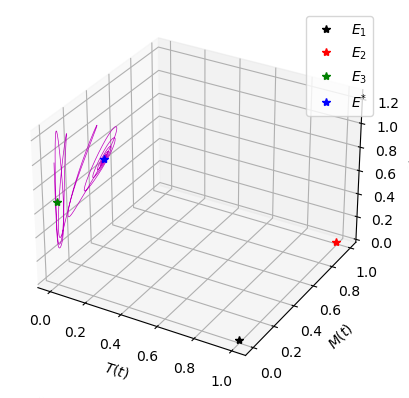

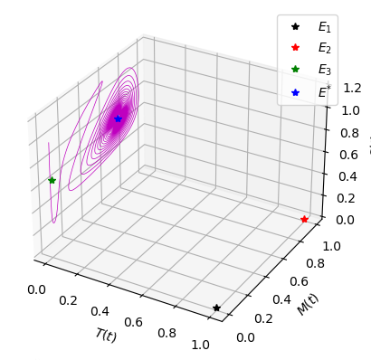

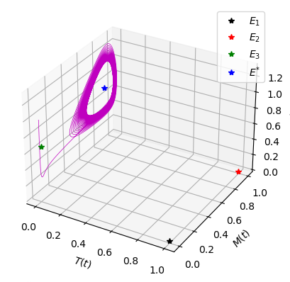

```python
# Condição inicial
TMC0=[2*10**6, 10**6, 10**7]
# time steps
t=np.linspace(0,600,100000) #(start,stop,num samples to generate)

alpha2=10**-8
sim1=odeint(sis, TMC0, t)

alpha2=3.333*10**-8
sim2=odeint(sis, TMC0, t)

alpha2=4.888*10**-8
sim3=odeint(sis, TMC0, t)

alpha2=8*10**-8
sim4=odeint(sis, TMC0, t)

fig1 = plt.figure()
ax = plt.axes(projection='3d')
ax.plot3D(sim1[:,0], sim1[:,1], sim1[:,2], 'm-', linewidth='0.5')
ax.plot3D(K1, 0, 0, '*k', label='$E_{1}$')
ax.plot3D(1000000000.00000 , 966000000.000000 , 0.0, '*r', label='$E_{2}$')
ax.plot3D(13000000.0000000 , 0.0 , 6810300.00000000, '*g', label='$E_{3}$')
ax.set_xlabel('$T(t)$')
ax.set_ylabel('$M(t)$')
ax.set_zlabel('$C(t)$')
plt.legend()
plt.show()

fig2 = plt.figure()
ax = plt.axes(projection='3d')
ax.plot3D(sim2[:,0], sim2[:,1], sim2[:,2], 'm-', linewidth='0.5')
ax.plot3D(K1, 0, 0, '*k', label='$E_{1}$')
ax.plot3D(1000000000.00000 , 989800000.000000 , 0.0, '*r', label='$E_{2}$')
ax.plot3D( 13000000.0000000 , 0.0 , 6810300.00000000, '*g', label='$E_{3}$')
ax.plot3D(17000000.0000000 , 399999999.999999 , 7406708.40000000, '*b', label='$E^{*}$')
ax.set_xlabel('$T(t)$')
ax.set_ylabel('$M(t)$')
ax.set_zlabel('$C(t)$')
plt.legend()

fig3 = plt.figure()
ax = plt.axes(projection='3d')
ax.plot3D(sim3[:,0], sim3[:,1], sim3[:,2], 'm-', linewidth='0.5')
ax.plot3D(K1, 0, 0, '*k', label='$E_{1}$')
ax.plot3D(1000000000.00000 , 993045454.545455 , 0.0 , '*r', label='$E_{2}$')
ax.plot3D(13000000.0000000 , 0.0 , 6810300.00000000 , '*g', label='$E_{3}$')
ax.plot3D(19418620.1736506 , 641862017.365055 , 7764866.05578093 , '*b', label='$E^{*}$')
ax.set_xlabel('$T(t)$')
ax.set_ylabel('$M(t)$')
ax.set_zlabel('$C(t)$')
plt.legend()

fig4 = plt.figure()
ax = plt.axes(projection='3d')
ax.plot3D(sim4[:,0], sim4[:,1], sim4[:,2], 'm-', linewidth='0.5')
ax.plot3D(K1, 0, 0, '*k', label='$E_{1}$')
ax.plot3D(1000000000.00000 , 995750000.000000 , 0.0, '*r', label='$E_{2}$')
ax.plot3D(13000000.0000000 , 0.0 , 6810300.00000000, '*g', label='$E_{3}$')
ax.plot3D(20973647.6607482 , 797364766.074821 , 7994159.28606397 , '*b', label='$E^{*}$')
ax.set_xlabel('$T(t)$')
ax.set_ylabel('$M(t)$')
ax.set_zlabel('$C(t)$')
plt.legend()
```

## **4th order Runge-Kutta method adapted to the model**

Algorithm adapted to remove oscillations around $C$ and used to formulate the scenarios.

```python
def RK(Tn,Mn,Cn,h,tmax,tanalise):
  npassos=tmax/h
  cont=1
  #We create empty lists to receive the results of the iterations
  tempo=0
  t=[]
  Tn1=[]
  Mn1=[]
  Cn1=[]
  #Lists that will receive the results of the iterations
  t.append(tempo)
  Tn1.append(Tn)
  Mn1.append(Mn)
  Cn1.append(Cn)


  for i in range(1,int(npassos+1)):
    k1=alpha1*Tn*(1-Tn/K1)*(1+beta1*Mn)-mu1*Cn*Tn
    l1=alpha2*Mn*Tn*(1-Mn/K2)-kappa2*Mn
    m1=alpha3*Cn*Tn-gamma3*Cn*Tn-theta3*Mn*Cn-kappa3*Cn

    k2=alpha1*(Tn+(0.5*h*k1))*(1-(Tn+(0.5*h*k1))/K1)*(1+beta1*(Mn+(0.5*h*l1)))-mu1*(Cn+(0.5*h*m1))*(Tn+(0.5*h*k1))
    l2=alpha2*(Mn+(0.5*h*l1))*(Tn+(0.5*h*k1))*(1-(Mn+(0.5*h*l1))/K2)-kappa2*(Mn+(0.5*h*l1))
    m2=alpha3*(Cn+(0.5*h*m1))*(Tn+(0.5*h*k1))-gamma3*(Cn+(0.5*h*m1))*(Tn+(0.5*h*k1))-kappa3*(Cn+(0.5*h*m1))-theta3*(Mn+(0.5*h*l1))*(Cn+(0.5*h*m1))

    k3=alpha1*(Tn+(0.5*h*k2))*(1-(Tn+(0.5*h*k2))/K1)*(1+beta1*(Mn+(0.5*h*l2)))-mu1*(Cn+(0.5*h*m2))*(Tn+(0.5*h*k2))
    l3=alpha2*(Mn+(0.5*h*l2))*(Tn+(0.5*h*k2))*(1-(Mn+(0.5*h*l2))/K2)-kappa2*(Mn+(0.5*h*l2))
    m3=alpha3*(Cn+(0.5*h*m2))*(Tn+(0.5*h*k2))-gamma3*(Cn+(0.5*h*m2))*(Tn+(0.5*h*k2))-kappa3*(Cn+(0.5*h*m2))-theta3*(Mn+(0.5*h*l2))*(Cn+(0.5*h*m2))

    k4=alpha1*(Tn+(h*k3))*(1-(Tn+(h*k3))/K1)*(1+beta1*(Mn+(h*l3)))-mu1*(Cn+(h*m3))*(Tn+(h*k3))
    l4=alpha2*(Mn+(h*l3))*(Tn+(h*k3))*(1-(Mn+(h*l3))/K2)-kappa2*(Mn+(h*l3))
    m4=alpha3*(Cn+(h*m3))*(Tn+(h*k3))-gamma3*(Cn+(h*m3))*(Tn+(h*k3))-kappa3*(Cn+(h*m3))-theta3*(Mn+(h*l3))*(Cn+(h*m3))

    Tn=Tn+(1.0/6.0)*h*(k1+2*k2+2*k3+k4)
    Mn=Mn+(1.0/6.0)*h*(l1+2*l2+2*l3+l4)
    #Cn=Cn+(1.0/6.0)*h*(m1+2*m2+2*m3+m4)

##### ROUTINE TO AVOID CART OSCILLATIONS #########
    tempo=tempo+h
    if (i > tanalise/h):
      aux=Cn+(1.0/6.0)*h*(m1+2*m2+2*m3+m4)
      if (Cn1[i-1]<=aux):
        Cn=Cn1[i-1]
        cont=0
      elif(cont==1):
        Cn=Cn+(1.0/6.0)*h*(m1+2*m2+2*m3+m4)
    else:
      Cn=Cn+(1.0/6.0)*h*(m1+2*m2+2*m3+m4)

    #The updated values are stored in the vectors
    Tn1.append(Tn)
    Mn1.append(Mn)
    Cn1.append(Cn)
    t.append(tempo)

  return[Tn1,Mn1,Cn1,t]
```

## **Initial tumour burden and CAR-T interaction with antigen changes the overall dynamics**

```python
#PARAMETERS
alpha1=0.69
beta1=2.3e-10
alpha2=1e-7
alpha3=5e-8
K1=1e9
K2=1e9
mu1=1e-6
kappa2=0.34
kappa3=0.13
theta3=5e-11
gamma3=4e-8

###RUNNING THE RKFUNCTION

tmax=80     #SIMULATION TIME IN DAYS
h=0.01      #TIME STEP

#THE LAST ENTRY OF THE RK FUNCTION DEFINES THE TIME WHEN THE POPULATION OF CAR T IS ALREADY DECREASING.
#INITIAL CONDITIONs
C1=[2.5e5, 1e6, 5e5]
S1tumor,S1macr,S1cart,S1tempo=RK(C1[0],C1[1],C1[2],h,tmax,20)

C1=[5e5, 1e6, 5e5]
S1tumor1,S1macr1,S1cart1,S1tempo1=RK(C1[0],C1[1],C1[2],h,tmax,20)

C1=[2.5e6, 1e6, 5e5]
S1tumor2,S1macr2,S1cart2,S1tempo2=RK(C1[0],C1[1],C1[2],h,tmax,15)

C1=[5e6, 1e6, 5e5]
S1tumor3,S1macr3,S1cart3,S1tempo3=RK(C1[0],C1[1],C1[2],h,tmax,15)
```

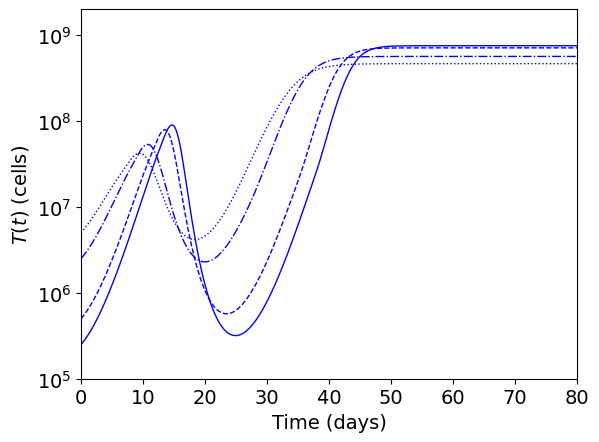

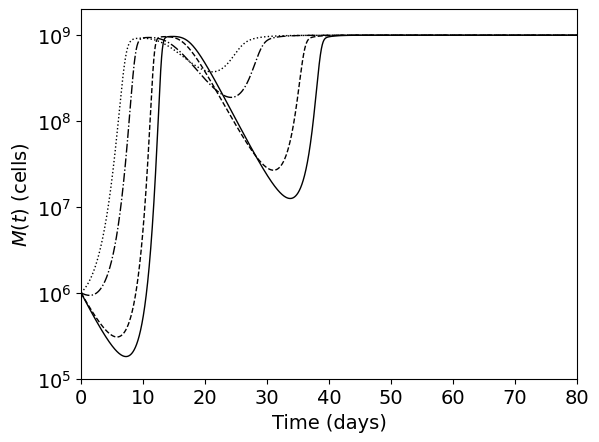

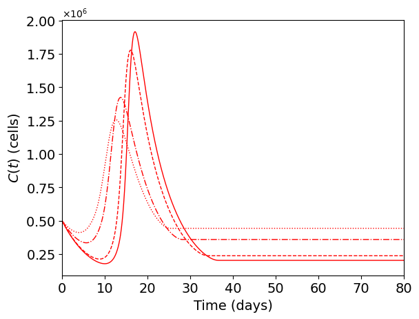

```python
x1=np.linspace(0,0,10);x2=np.linspace(tmax,tmax,10)

fig, ax = plt.subplots()

plt.plot(S1tempo, S1tumor, label= r'T(0)=2.5x$10^{5}$ cells ' , color='b',linestyle='solid',linewidth=1.0)
plt.plot(S1tempo, S1tumor1, label= r'T(0)=5x$10^{5}$ cells' , color='b',linestyle='dashed',linewidth=1.0)
plt.plot(S1tempo, S1tumor2, label= r'T(0)=2.5x$10^{6}$ cells' , color='b',linestyle='dashdot',linewidth=1.0)
plt.plot(S1tempo, S1tumor3, label= r'T(0)=5x$10^{6}$ cells' , color='b',linestyle='dotted',linewidth=1.0)
plt.fill_betweenx(y=np.linspace(0,100,10), x1=0, x2=tmax, where = x2 >= x1,color='grey',alpha=0.2)
plt.xlim(0,tmax)
plt.ylim(1e5,2e9)
#plt.legend(ncol=1,loc='best')
#plt.legend(loc='center', bbox_to_anchor=(0.5, 1.1), ncol=2,columnspacing=1.0,handletextpad=0.1,frameon=False, shadow=True,fontsize = 12)
plt.yticks(fontsize=14)
plt.xticks(fontsize=14)
plt.xlabel('Time (days)',size=14)
plt.ylabel('$T(t)$ (cells)',size=14)
plt.yscale("log")
ax.minorticks_off()
plt.savefig("TUM2 - CITUMOR 1e-8.pdf")
#plt.close()
plt.show()

fig, ax = plt.subplots()

plt.plot(S1tempo, S1macr, label= r'T(0)=2.5x$10^{5}$ cells' , color='k',linestyle='solid',linewidth=1.0)
plt.plot(S1tempo, S1macr1, label= r'T(0)=5x$10^{5}$ cells' , color='k',linestyle='dashed',linewidth=1.0)
plt.plot(S1tempo, S1macr2, label= r'T(0)=2.5x$10^{6}$ cells' , color='k',linestyle='dashdot',linewidth=1.0)
plt.plot(S1tempo, S1macr3, label= r'T(0)=5x$10^{6}$ cells' , color='k',linestyle='dotted',linewidth=1.0)
plt.xlim(0,tmax)
plt.ylim(1e5,2e9)

#plt.legend(loc='center', bbox_to_anchor=(0.5, 1.1), ncol=2,columnspacing=1.0,handletextpad=0.1,frameon=False, shadow=True,fontsize = 12)
plt.yticks(fontsize=14)
plt.xticks(fontsize=14)
plt.xlabel('Time (days)',size=14)
plt.ylabel('$M(t)$ (cells)',size=14)
plt.yscale("log")
ax.minorticks_off()
plt.savefig("MAC2 - CITUMOR 1e-8.pdf")
#plt.close()
plt.show()


fig, ax = plt.subplots()

plt.plot(S1tempo, S1cart, label= r'T(0)=2.5x$10^{5}$ cells  ' , color='r',linestyle='solid',linewidth=1.0)
plt.plot(S1tempo, S1cart1, label= r'T(0)=5x$10^{5}$ cells  ' , color='r',linestyle='dashed',linewidth=1.0)
plt.plot(S1tempo, S1cart2, label= r'T(0)=2.5x$10^{6}$ cells ' , color='r',linestyle='dashdot',linewidth=1.0)
plt.plot(S1tempo, S1cart3, label= r'T(0)=5x$10^{6}$ cells ' , color='r',linestyle='dotted',linewidth=1.0)
plt.xlim(0,tmax)
#plt.ylim(0,5e7)
#plt.legend(loc='center', bbox_to_anchor=(0.5, 1.1), ncol=2,columnspacing=1.0,handletextpad=0.1,frameon=False, shadow=True,fontsize = 12)
plt.yticks(fontsize=14)
plt.xticks(fontsize=14)
yScalarFormatter = matplotlib.ticker.ScalarFormatter(useMathText=True)
yScalarFormatter.set_powerlimits((0,2))
ax.yaxis.set_major_formatter(yScalarFormatter)
plt.xlabel('Time (days)',size=14)
plt.ylabel('$C(t)$ (cells)',size=14 )
plt.savefig("CAR - CITUMOR 1e-8.pdf")
#plt.close()
plt.show()
```

```python
alpha1=0.69
beta1=2.3e-10
alpha2=1e-7
alpha3=5e-8
K1=1e9
K2=1e9
mu1=1e-7
kappa2=0.34
kappa3=0.13
gamma3=4e-8
theta3=5e-11

tmax=80
h=0.01

C1=[2e6, 1e6, 2.5e5]
S1tumor,S1macr,S1cart,S1tempo=RK(C1[0],C1[1],C1[2],h,tmax,20)

C1=[2e6, 1e6, 5e5]
S1tumor1,S1macr1,S1cart1,S1tempo1=RK(C1[0],C1[1],C1[2],h,tmax,20)

C1=[2e6, 1e6, 2.5e6]
S1tumor2,S1macr2,S1cart2,S1tempo2=RK(C1[0],C1[1],C1[2],h,tmax,15)

C1=[2e6, 1e6, 5e6]
S1tumor3,S1macr3,S1cart3,S1tempo3=RK(C1[0],C1[1],C1[2],h,tmax,15)
```

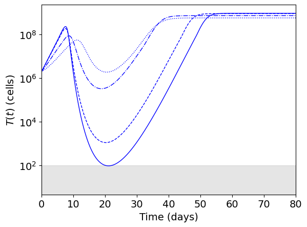

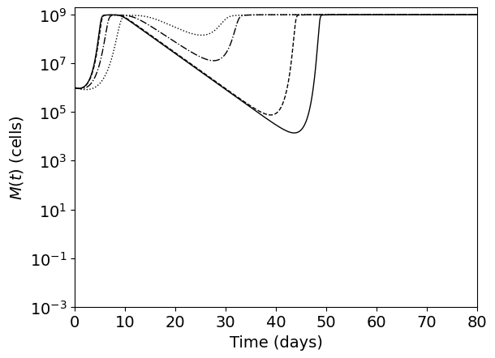

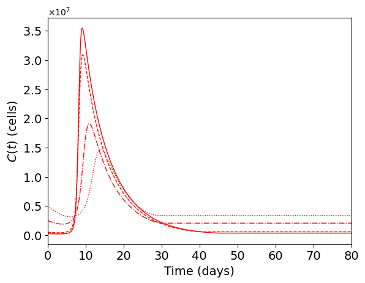

```python
x1=np.linspace(0,0,10);x2=np.linspace(tmax,tmax,10)

fig, ax = plt.subplots()

plt.plot(S1tempo, S1tumor, label= r'C(0)=2.5x$10^{5}$ cells ' , color='b',linestyle='solid',linewidth=1.0)
plt.plot(S1tempo, S1tumor1, label= r'C(0)=5x$10^{5}$ cells' , color='b',linestyle='dashed',linewidth=1.0)
plt.plot(S1tempo, S1tumor2, label= r'C(0)=2.5x$10^{6}$ cells' , color='b',linestyle='dashdot',linewidth=1.0)
plt.plot(S1tempo, S1tumor3, label= r'C(0)=5x$10^{6}$ cells' , color='b',linestyle='dotted',linewidth=1.0)
plt.fill_betweenx(y=np.linspace(0,100,10), x1=0, x2=tmax, where = x2 >= x1,color='grey',alpha=0.2)
plt.xlim(0,tmax)
#plt.ylim(1e-2,2e9)
#plt.legend(ncol=1,loc='best')
#plt.legend(loc='center', bbox_to_anchor=(0.5, 1.1), ncol=2,columnspacing=1.0,handletextpad=0.1,frameon=False, shadow=True,fontsize = 12)
plt.yticks(fontsize=14)
plt.xticks(fontsize=14)
plt.xlabel('Time (days)',size=14)
plt.ylabel('$T(t)$ (cells)',size=14)
plt.yscale("log")
plt.savefig("TUM2 - CICAR 1e-7.pdf")
#plt.close()
plt.show()

fig, ax = plt.subplots()

plt.plot(S1tempo, S1macr, label= r'C(0)=2.5x$10^{5}$ cells' , color='k',linestyle='solid',linewidth=1.0)
plt.plot(S1tempo, S1macr1, label= r'C(0)=5x$10^{5}$ cells' , color='k',linestyle='dashed',linewidth=1.0)
plt.plot(S1tempo, S1macr2, label= r'C(0)=2.5x$10^{6}$ cells' , color='k',linestyle='dashdot',linewidth=1.0)
plt.plot(S1tempo, S1macr3, label= r'C(0)=5x$10^{6}$ cells' , color='k',linestyle='dotted',linewidth=1.0)
plt.xlim(0,tmax)
plt.ylim(1e-3,2e9)

#plt.legend(loc='center', bbox_to_anchor=(0.5, 1.1), ncol=2,columnspacing=1.0,handletextpad=0.1,frameon=False, shadow=True,fontsize = 12)
plt.yticks(fontsize=14)
plt.xticks(fontsize=14)
plt.xlabel('Time (days)',size=14)
plt.ylabel('$M(t)$ (cells)',size=14)
plt.yscale("log")
ax.minorticks_off()
plt.savefig("MAC2 - CICAR 1e-7.pdf")
#plt.close()
plt.show()


fig, ax = plt.subplots()

plt.plot(S1tempo, S1cart, label= r'C(0)=2.5x$10^{5}$ cells  ' , color='r',linestyle='solid',linewidth=1.0)
plt.plot(S1tempo, S1cart1, label= r'C(0)=5x$10^{5}$ cells  ' , color='r',linestyle='dashed',linewidth=1.0)
plt.plot(S1tempo, S1cart2, label= r'C(0)=2.5x$10^{6}$ cells ' , color='r',linestyle='dashdot',linewidth=1.0)
plt.plot(S1tempo, S1cart3, label= r'C(0)=5x$10^{6}$ cells ' , color='r',linestyle='dotted',linewidth=1.0)
plt.xlim(0,tmax)
#plt.ylim(0,5e7)
#plt.legend(loc='center', bbox_to_anchor=(0.5, 1.1), ncol=2,columnspacing=1.0,handletextpad=0.1,frameon=False, shadow=True,fontsize = 12)
plt.yticks(fontsize=14)
plt.xticks(fontsize=14)
yScalarFormatter = matplotlib.ticker.ScalarFormatter(useMathText=True)
yScalarFormatter.set_powerlimits((0,2))
ax.yaxis.set_major_formatter(yScalarFormatter)
plt.xlabel('Time (days)',size=14)
plt.ylabel('$C(t)$ (cells)',size=14)
plt.savefig("CAR - CICAR 1e-7.pdf")
#plt.close()
plt.show()
```

## **TAM inhibition affects tumor control**

```python
alpha1=0.69
beta1=2.3e-10
alpha2=1e-7
alpha3=5e-8
K1=1e9
K2=1e9
mu1=1e-7
kappa2=0.34
kappa3=0.13
gamma3=4e-8


C1=[2e6, 1e6, 1e5]

theta3=0
S1tumor,S1macr,S1cart,S1tempo=RK(C1[0],C1[1],C1[2],h,tmax,15)

theta3=5e-11
C1=[2e6, 1e6, 1e5]
S1tumor1,S1macr1,S1cart1,S1tempo1=RK(C1[0],C1[1],C1[2],h,tmax,15)

theta3=1e-10
C1=[2e6, 1e6, 1e5]
S1tumor2,S1macr2,S1cart2,S1tempo2=RK(C1[0],C1[1],C1[2],h,tmax,15)

theta3=5e-9
C1=[2e6, 1e6, 1e5]
S1tumor3,S1macr3,S1cart3,S1tempo3=RK(C1[0],C1[1],C1[2],h,tmax,15)
```

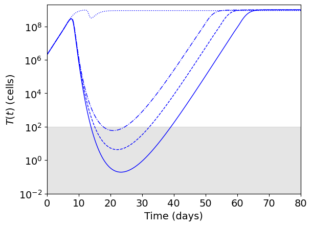

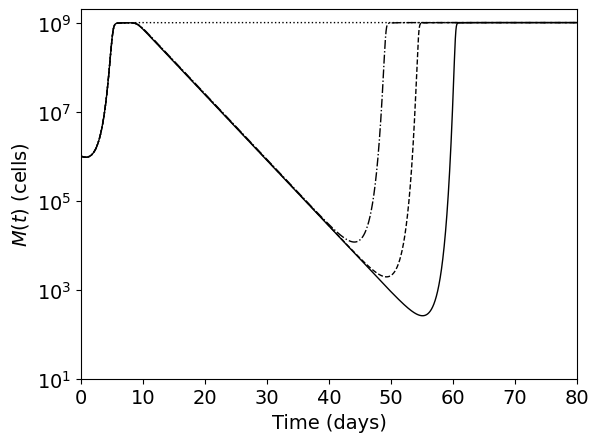

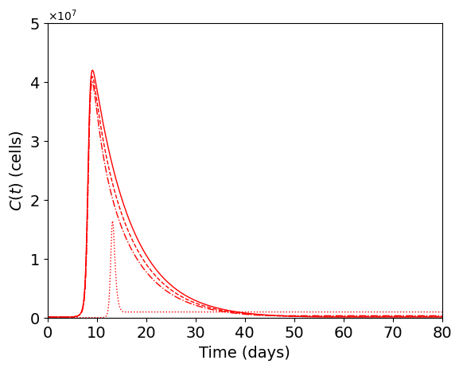

```python
x1=np.linspace(0,0,10);x2=np.linspace(tmax,tmax,10)
fig, ax = plt.subplots()

plt.plot(S1tempo, S1tumor, label= r'$\theta_3=0$ ' , color='b',linestyle='solid',linewidth=1.0)
plt.plot(S1tempo, S1tumor1, label= r'$\theta_3=5.10^{-11}$ ' , color='b',linestyle='dashed',linewidth=1.0)
plt.plot(S1tempo, S1tumor2, label= r'$\theta_3=10^{-10}$ ' , color='b',linestyle='dashdot',linewidth=1.0)
plt.plot(S1tempo, S1tumor3, label= r'$\theta_3=5.10^{-10}$ ' , color='b',linestyle='dotted',linewidth=1.0)
plt.fill_betweenx(y=np.linspace(0,100,10), x1=0, x2=tmax, where = x2 >= x1,color='grey',alpha=0.2)
plt.xlim(0,tmax)
plt.ylim(1e-2,2e9)
#plt.legend(ncol=1,loc='best')
# plt.legend(loc='center', bbox_to_anchor=(0.85, 0.5), ncol=1,columnspacing=1.0,handletextpad=0.1,frameon=False, shadow=True,fontsize = 14)
# ax.annotate(r"$\theta_3$ (cell.day)$^{-1}$ ",
#             xy=(60, 0.9e6),
#             size = 13)
plt.yticks(fontsize=14)
plt.xticks(fontsize=14)
plt.xlabel('Time (days)',size=14)
plt.ylabel('$T(t)$ (cells)',size=14)
plt.yscale("log")
plt.savefig("TUM2 - theta3.pdf")
#plt.close()
plt.show()

fig, ax = plt.subplots()

plt.plot(S1tempo, S1macr, label= r'$\theta_3=0$ ' , color='k',linestyle='solid',linewidth=1.0)
plt.plot(S1tempo, S1macr1, label= r'$\theta_3=5.10^{-11}$ ' , color='k',linestyle='dashed',linewidth=1.0)
plt.plot(S1tempo, S1macr2, label= r'$\theta_3=10^{-10}$ ' , color='k',linestyle='dashdot',linewidth=1.0)
plt.plot(S1tempo, S1macr3, label= r'$\theta_3=5.10^{-10}$ ' , color='k',linestyle='dotted',linewidth=1.0)
#plt.fill_betweenx(y=np.linspace(0,100,10), x1=0, x2=tmax, where = x2 >= x1,color='grey',alpha=0.2)
plt.xlim(0,tmax)
plt.ylim(1e1,2e9)

# plt.legend(loc='center', bbox_to_anchor=(0.15, 0.4), ncol=1,columnspacing=1.0,handletextpad=0.1,frameon=False, shadow=True,fontsize = 14)
# ax.annotate(r"$\theta_3$ (cell.day)$^{-1}$ ",
#             xy=(0.75, 0.6e6),
#             size = 13)
plt.yticks(fontsize=14)
plt.xticks(fontsize=14)
plt.xlabel('Time (days)',size=14)
plt.ylabel('$M(t)$ (cells)',size=14)
plt.yscale("log")
plt.savefig("MAC2 - theta3.pdf")
#plt.close()
plt.show()


fig, ax = plt.subplots()

plt.plot(S1tempo, S1cart, label= r'$\theta_3=0$ ' , color='r',linestyle='solid',linewidth=1.0)
plt.plot(S1tempo, S1cart1, label= r'$\theta_3=5.10^{-11}$ ' , color='r',linestyle='dashed',linewidth=1.0)
plt.plot(S1tempo, S1cart2, label= r'$\theta_3=10^{-10}$ ' , color='r',linestyle='dashdot',linewidth=1.0)
plt.plot(S1tempo, S1cart3, label= r'$\theta_3=5.10^{-10}$ ' , color='r',linestyle='dotted',linewidth=1.0)
plt.fill_betweenx(y=np.linspace(0,100,10), x1=0, x2=tmax, where = x2 >= x1,color='grey',alpha=0.2)
plt.xlim(0,tmax)
plt.ylim(0,5e7)
#plt.legend(ncol=1,loc='best')
# plt.legend(loc='center', bbox_to_anchor=(0.85, 0.75), ncol=1,columnspacing=1.0,handletextpad=0.1,frameon=False, shadow=True,fontsize = 14)
# ax.annotate(r"$\theta_3$ (cell.day)$^{-1}$ ",
#             xy=(60, 4.75e7),
#             size = 13)
plt.yticks(fontsize=14)
plt.xticks(fontsize=14)
yScalarFormatter = matplotlib.ticker.ScalarFormatter(useMathText=True)
yScalarFormatter.set_powerlimits((0,2))
ax.yaxis.set_major_formatter(yScalarFormatter)
plt.xlabel('Time (days)',size=14)
plt.ylabel('$C(t)$ (cells)',size=14)
plt.savefig("CAR - theta3.pdf")
#plt.close()
plt.show()
```

## **Sensitivity analysis**

We performe a sensitivity analysis using the elemtary effects (EE) and the adapted algorithm.

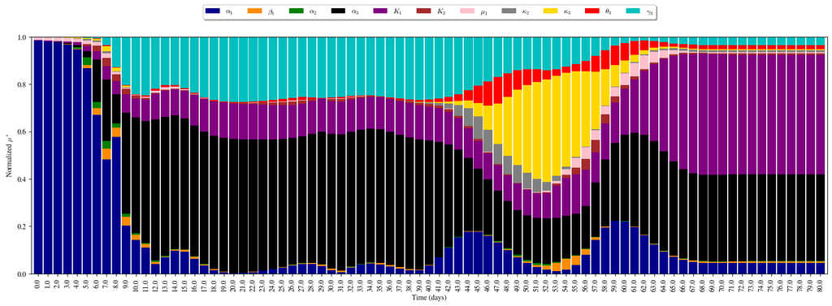

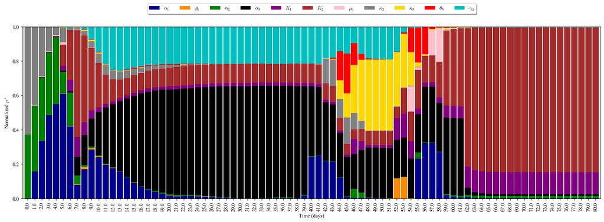

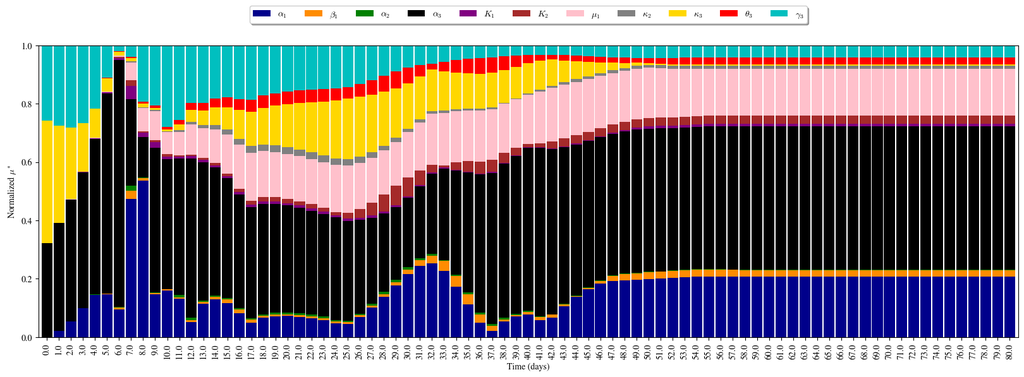

```python
import numpy as np
import pandas as pd
import matplotlib.pyplot as plt
from SALib.sample.morris import sample as ee_sample

##### Makes graphics font look like LaTeX font
import matplotlib
matplotlib.rcParams['mathtext.fontset'] = 'cm'
matplotlib.rcParams['font.family'] = 'STIXGeneral'

##### RK4 OF THE PROPOSED MODEL #####
def RK(y0,t_eval,alpha1,beta1,alpha2,alpha3,K1,K2,mu1,kappa2,kappa3,theta3,gamma3):

    Tn=y0[0];Mn=y0[1];Cn=y0[2]
    npassos=len(t_eval)
    tanalise=40

    cont=1

    tempo=0
    t=[]
    Tn1=[]
    Mn1=[]
    Cn1=[]

    t.append(tempo)
    Tn1.append(Tn)
    Mn1.append(Mn)
    Cn1.append(Cn)


    for i in range(1,int(npassos)):
        k1=alpha1*Tn*(1-(Tn/K1))*(1+beta1*Mn)-mu1*Cn*Tn
        l1=alpha2*Mn*Tn*(1-(Mn/K1))-kappa2*Mn
        m1=(alpha3*Cn*Tn)-(gamma3*Cn*Tn)-kappa3*Cn-theta3*Mn*Cn

        k2=alpha1*(Tn+(0.5*h*k1))*(1-((Tn+(0.5*h*k1))/K1))*(1+beta1*(Mn+(0.5*h*l1)))-mu1*(Cn+(0.5*h*m1))*(Tn+(0.5*h*k1))
        l2=alpha2*(Mn+(0.5*h*l1))*(Tn+(0.5*h*k1))*(1-((Mn+(0.5*h*l1))/K2))-kappa2*(Mn+(0.5*h*l1))
        m2=(alpha3*(Cn+(0.5*h*m1))*(Tn+(0.5*h*k1)))-(gamma3*(Cn+(0.5*h*m1))*(Tn+(0.5*h*k1)))-kappa3*(Cn+(0.5*h*m1))-theta3*(Mn+(0.5*h*l1))*(Cn+(0.5*h*m1))

        k3=alpha1*(Tn+(0.5*h*k2))*(1-((Tn+(0.5*h*k2))/K1))*(1+beta1*(Mn+(0.5*h*l2)))-mu1*(Cn+(0.5*h*m2))*(Tn+(0.5*h*k2))
        l3=alpha2*(Mn+(0.5*h*l2))*(Tn+(0.5*h*k2))*(1-((Mn+(0.5*h*l2))/K2))-kappa2*(Mn+(0.5*h*l2))
        m3=(alpha3*(Cn+(0.5*h*m2))*(Tn+(0.5*h*k2)))-(gamma3*(Cn+(0.5*h*m2))*(Tn+(0.5*h*k2)))-kappa3*(Cn+(0.5*h*m2))-theta3*(Mn+(0.5*h*l2))*(Cn+(0.5*h*m2))

        k4=alpha1*(Tn+(h*k3))*(1-((Tn+(h*k3))/K1))*(1+beta1*(Mn+(h*l3)))-mu1*(Cn+(h*m3))*(Tn+(h*k3))
        l4=alpha2*(Mn+(h*l3))*(Tn+(h*k3))*(1-((Mn+(h*l3))/K2))-kappa2*(Mn+(h*l3))
        m4=(alpha3*(Cn+(h*m3))*(Tn+(h*k3)))-(gamma3*(Cn+(h*m3))*(Tn+(h*k3)))-kappa3*(Cn+(h*m3))-theta3*(Mn+(h*l3))*(Cn+(h*m3))

        Tn=Tn+(1.0/6.0)*h*(k1+2*k2+2*k3+k4)
        Mn=Mn+(1.0/6.0)*h*(l1+2*l2+2*l3+l4)
        #Cn=Cn+(1.0/6.0)*h*(m1+2*m2+2*m3+m4)

    ##### ROUTINE TO AVOID CART OSCILLATIONS #########
        tempo=tempo+h
        if (i > tanalise/h):
            aux=Cn+(1.0/6.0)*h*(m1+2*m2+2*m3+m4)
            if (Cn1[i-1]<=aux):
                Cn=Cn1[i-1]
                cont=0
            elif(cont==1):
                Cn=Cn+(1.0/6.0)*h*(m1+2*m2+2*m3+m4)
        else:
            Cn=Cn+(1.0/6.0)*h*(m1+2*m2+2*m3+m4)


        Tn1.append(Tn)
        Mn1.append(Mn)
        Cn1.append(Cn)
        t.append(tempo)

    return[Tn1,Mn1,Cn1]


##### WRAPPER: ALLOWS THE MODEL TO ROLL AGAIN WITH NEW PARAMETER SETS #####
def modelo_wrapper(
    y0,
    t_eval,
    alpha1,beta1,alpha2,alpha3,K1,K2,mu1,kappa2,kappa3,theta3,gamma3):

    ##### Adapted 4th order Runge-Kutta method
    solution_prob = RK(y0,t_eval,alpha1,beta1,alpha2,alpha3,K1,K2,mu1,kappa2,kappa3,theta3,gamma3)

    return solution_prob


########### MODEL PARAMETERS ######################

alpha1=0.69 ;beta1=2.3e-10
alpha2=1e-7;alpha3=5e-8
K1=1e9 ;K2=1e9
mu1=1e-7
kappa2=0.34 ;kappa3=0.13
theta3=1e-10 #Enter too small a number, method does not accept zero
gamma3=4e-8

########### INITIAL CONDITIONS ######################
TUMOR_ic = 2e6
MAC_ic = 1e6
CAR_ic = 1e5
y0_modelo = TUMOR_ic,MAC_ic,CAR_ic

### TIME ###
tmax=80
h=0.01
times = np.arange(0,tmax+1,h)

##### THE DECLARED PARAMETERS ARE ENTERED AS THE AVERAGE SENSITIVITY PARAMETERS #####

mean_values_params = [alpha1,beta1,alpha2,alpha3,K1,K2,mu1,kappa2,kappa3,theta3,gamma3]
factors_names = [
    r'$\alpha_1$',
    r'$\beta_1$',
    r'$\alpha_2$',
    r'$\alpha_3$',
    r'$K_1$',
    r'$K_2$',
    r'$\mu_1$',
    r'$\kappa_2$',
    r'$\kappa_3$',
    r'$\theta_3$',
    r'$\gamma_3$'
]

##### Problem definition
seed = 1234
params_perturbations = 0.25 #####  Parameter variation 25%

problem_info = {
    'num_vars': len(mean_values_params),
    'names': factors_names,
    'bounds': [[param - params_perturbations * param, param + params_perturbations * param] for param in mean_values_params]
}

#####  Parameters of the Elem. Effects
grid_level = 4 ##### p - levels
num_of_trajectories = 40 ##### r-trajectories
parameter_values = ee_sample(problem_info, grid_level, num_of_trajectories, local_optimization=False, seed=seed) ##### Gera vários "sets" de parâmetros

##### Defining output arrays

num_of_experimental_points = len(times) #Number of observations/experimental points analyzed
num_of_realizations = parameter_values.shape[0] #Number of samples (number of parameter sets generated by Elem. Effects)

#####  We will analyze sensitivity for 1-Tumor, 2-Macrophage, 3-CART
qoi_sensitivity_outputs1 = np.zeros([num_of_realizations, num_of_experimental_points])
qoi_sensitivity_outputs2 = np.zeros([num_of_realizations, num_of_experimental_points])
qoi_sensitivity_outputs3 = np.zeros([num_of_realizations, num_of_experimental_points])

##### Tests and saves result in all previously generated parameter sets
for realization_index, parameters_realization in enumerate(parameter_values):

    realization_model = modelo_wrapper(y0_modelo, times, *parameters_realization)

    tumor_sol= realization_model[0]
    mac_sol= realization_model[1]
    car_sol= realization_model[2]

    qoi_sensitivity_outputs1[realization_index, :] = tumor_sol #Amount of interest - tumor
    qoi_sensitivity_outputs2[realization_index, :] = mac_sol #Amount of interest - TAM
    qoi_sensitivity_outputs3[realization_index, :] = car_sol #Amount of interest - CART

##### Collecting and processing the results
from SALib.analyze.morris import analyze as ee_analyze

Si_list1 = list()
df_Si1 = pd.DataFrame(columns=['Time (days)', *problem_info['names']]) #names columns
df_Si1['Time (days)'] = times.round(1) #fills column  'Time (days)'

Si_list2 = list()
df_Si2 = pd.DataFrame(columns=['Time (days)', *problem_info['names']]) #nomeia colunas
df_Si2['Time (days)'] = times.round(1) #fills column  'Time (days)'

Si_list3 = list()
df_Si3 = pd.DataFrame(columns=['Time (days)', *problem_info['names']]) #nomeia colunas
df_Si3['Time (days)'] = times.round(1) #fills column  'Time (days)'

##### Run the EE
for experimental_point in range(num_of_experimental_points):#number of observations/experimental points collected
    Si1 = ee_analyze(problem_info, parameter_values, qoi_sensitivity_outputs1[:, experimental_point], conf_level=0.95,
                     print_to_console=False,num_levels=grid_level, seed=seed, num_resamples=100)

    Si2 = ee_analyze(problem_info, parameter_values, qoi_sensitivity_outputs2[:, experimental_point], conf_level=0.95,
                     print_to_console=False,num_levels=grid_level, seed=seed, num_resamples=100)

    Si3 = ee_analyze(problem_info, parameter_values, qoi_sensitivity_outputs3[:, experimental_point], conf_level=0.95,
                     print_to_console=False,num_levels=grid_level, seed=seed, num_resamples=100)


    Si1['mu_star_normalized'] = Si1['mu_star'] / Si1['mu_star'].sum()
    Si_list1.append(Si1)

    Si2['mu_star_normalized'] = Si2['mu_star'] / Si2['mu_star'].sum()
    Si_list2.append(Si2)

    Si3['mu_star_normalized'] = Si3['mu_star'] / Si3['mu_star'].sum()
    Si_list3.append(Si3)


    for idx, param_name in enumerate(problem_info['names']):
        df_Si1.loc[experimental_point, param_name] = Si1['mu_star_normalized'][idx]
        df_Si2.loc[experimental_point, param_name] = Si2['mu_star_normalized'][idx]
        df_Si3.loc[experimental_point, param_name] = Si3['mu_star_normalized'][idx]

#####  Organize the results
df_Si1.sort_values(by='Time (days)', inplace=True)
df_Si1.drop(index=0, inplace=True)

df_Si2.sort_values(by='Time (days)', inplace=True)
df_Si2.drop(index=0, inplace=True)

df_Si3.sort_values(by='Time (days)', inplace=True)
df_Si3.drop(index=0, inplace=True)

##### Viewing the results

c = ['darkblue','darkorange','green','black','purple','brown','pink','gray','gold','red','c']

fig = plt.figure()
ax = plt.subplot(111)
day_step_to_plot = int(1/h)
df_Si1[::day_step_to_plot].plot.bar(x='Time (days)', rot=90, width=0.9, figsize=(20, 6), stacked=True, ax=ax,color = c)
plt.ylabel(r"Normalized $\mu^*$")

plt.ylim([0, 1])
ax.legend(loc='upper center', bbox_to_anchor=(0.5, 1.15), ncol=len(problem_info['names']), fancybox=True, shadow=True)

plt.savefig('SENSITIVITY ADAPTED-TUMOR_2.pdf', bbox_inches="tight")
plt.show()

fig = plt.figure()
ax = plt.subplot(111)
day_step_to_plot = int(1/h)
df_Si2[::day_step_to_plot].plot.bar(x='Time (days)', rot=90, width=0.9, figsize=(20, 6), stacked=True, ax=ax,color = c)
plt.ylabel(r"Normalized $\mu^*$")

plt.ylim([0, 1])
ax.legend(loc='upper center', bbox_to_anchor=(0.5, 1.15), ncol=len(problem_info['names']), fancybox=True, shadow=True)

plt.savefig('SENSITIVITY ADAPTED-MAC_2.pdf', bbox_inches="tight")
plt.show()

fig = plt.figure()
ax = plt.subplot(111)
day_step_to_plot = int(1/h)
df_Si3[::day_step_to_plot].plot.bar(x='Time (days)', rot=90, width=0.9, figsize=(20, 6), stacked=True, ax=ax,color = c)
plt.ylabel(r"Normalized $\mu^*$")

plt.ylim([0, 1])
ax.legend(loc='upper center', bbox_to_anchor=(0.5, 1.15), ncol=len(problem_info['names']), fancybox=True, shadow=True)

plt.savefig('SENSITIVITY ADAPTED-CAR_2.pdf', bbox_inches="tight")
plt.show()
```